## Analyse des données Licence Pro 2025-2026

### Présentation du cours

#### Florian Bayer

### Déroulement des séances

- 4 séances de 3 heures
- CM puis TD
- florian.bayer@gmail.com

### Contenu de l'enseignement

##### Démarche scientifique

**Acquérir les bonnes pratiques de la démarche scientifique** : Introduction aux méthodes rigoureuses de recherche et d'analyse scientifique.

##### Statistiques appliquées

**Les statistiques appliquées à la cartographie** : Compréhension des concepts statistiques et de leur utilisation pour l'analyse et la représentation géographique des données.

##### Traitement des données

**Principes et méthodes de traitement en analyse de données** : Initiation aux bases de l'analyse de données et l'interprétation des résultats. La collecte des données n'est pas abordée.

### Contenu de l'enseignement (2)

##### Analyse univariée et bivariée

**Analyse univariée et bivariée** sur des données quantitatives : Exploration des techniques d'analyse de variables uniques et des relations entre deux variables (corrélation).

##### Méthodes de discrétisation

**Méthodes de discrétisation** : Techniques de regroupement des données en classes pour une meilleure interprétation visuelle.

##### Séances de TD pratiques

**Séances de TD pratiques** : Des travaux dirigés permettent aux étudiants de mettre en pratique les connaissances acquises à travers des exercices concrets.

### Contenu de l'enseignement

### Univarié

- Distinguer les types de **variables**, de **distributions**. **Décrire** une série de données, utiliser les **méthodes appropriées** à chaque type de données.
- Connaître les **principes** et **méthodes** de traitement et d'analyse de données.
- Maîtriser différentes méthodes de **représentation** de l'information statistique en géographie (notamment graphiques et cartographiques).
- N.B. L'analyse univariée est une étape obligatoire avant toutes les analyses statistiques les plus complexes.

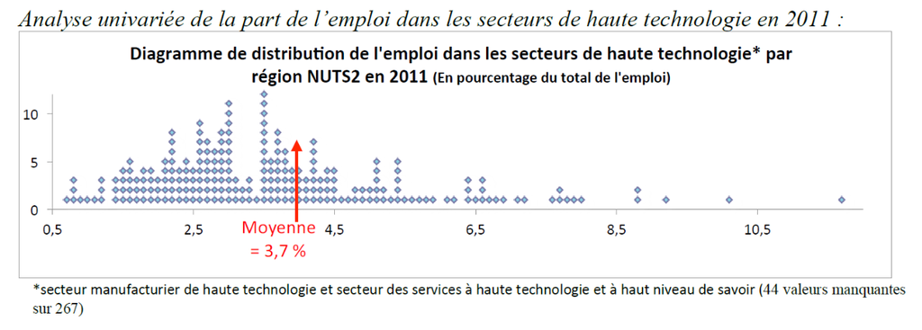

### Discrétisation

En fonction de votre analyse univariée, de vos objectifs et de votre public : - Appliquer la méthode de discrétisation la plus adaptée

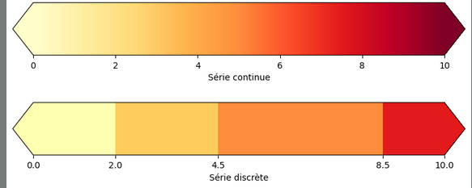

### Bivarié

- Mesurer l'**intensité** de la **relation** entre deux variables *quantitatives* à l'aide de la corrélation.
- **Modéliser** la nature d'une relation entre deux variables à l'aide des analyses de régression linéaire.

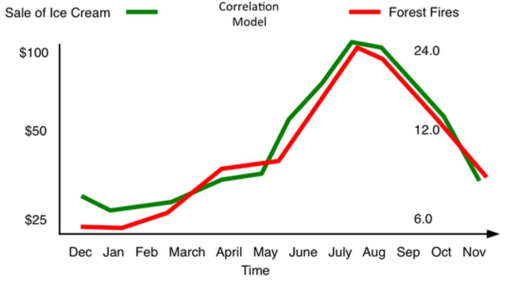

### Exemple d'application

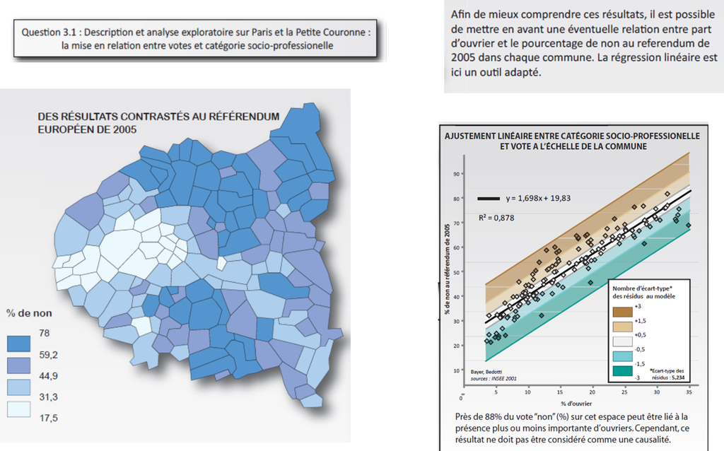

### Exemple d'application

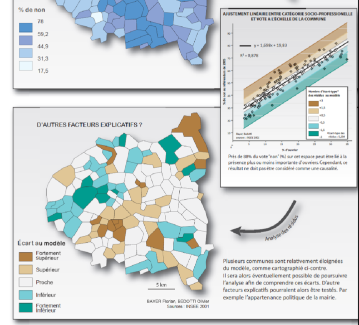

### Exemple (non abordé cette année)

[figure not shown]

### Exemples (non abordé cette année)

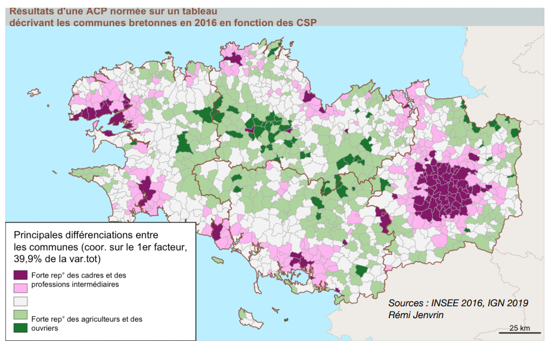